# 2. Rock Paper Scissors Stochastic Reaction Diffusion

Author

Nathan Zimmerberg

Published

February 13, 2023

# 2. Rock Paper Scissors Stochastic Reaction Diffusion

Inspired by:

https://www.youtube.com/watch?v=TORwMc2AaRE&t=0s

## Setup

Open a julia REPL or jupyter notebook using the `medyan-tutorial` environment you created in tutorial 1.

Load `MEDYAN` with `MEDYANVis` for visualization

```julia
using MEDYAN
using MEDYANVis
using CairoMakie
using Random
using SmallZarrGroups
Random.seed!(1234);
```

## Defining System

The first step is to create a system definition (`MEDYAN.SysDef`).

This system will contain three diffusing species: Rock, Paper, and Scissors.

We create the species using `def_diffusing_species!`, which takes the species name and diffusion coefficient.

All units are based on nm, s, pN.

```julia
s = MEDYAN.SysDef()
D = 1E6 # nm²/s
def_diffusing_species!(s, :R; coeff=D) # Rock
def_diffusing_species!(s, :P; coeff=D) # Paper
def_diffusing_species!(s, :S; coeff=D) # Scissors
```

```
MEDYAN.SysDef with:
 Diffusing species:
  :R: 1.0e6 nm²·s⁻¹ (1.0 µm²·s⁻¹)
  :P: 1.0e6 nm²·s⁻¹ (1.0 µm²·s⁻¹)
  :S: 1.0e6 nm²·s⁻¹ (1.0 µm²·s⁻¹)
```

## Adding Reactions

Paper “beats” rock, scissors “beats” paper, rock “beats” scissors. In this simulation “beats” means convert to self type.

In this case because the reaction is between two diffusing species, it has units of nm³/s. You can think of this as the volume where if exactly one of each reactant existed the rate would be 1 per second.

`def_reaction!`

```julia
rate = 50.0*(500.0^3) # nm³/s
def_reaction!(s, "diffusing.P + diffusing.R --> 2diffusing.P";
    base_rate=rate,
    invvolumepower=1,
)
def_reaction!(s, "diffusing.S + diffusing.P --> 2diffusing.S";
    base_rate=rate,
    invvolumepower=1,
)
def_reaction!(s, "diffusing.R + diffusing.S --> 2diffusing.R";
    base_rate=rate,
    invvolumepower=1,
)
```

```
MEDYAN.SysDef with:
 Diffusing species:
  :R: 1.0e6 nm²·s⁻¹ (1.0 µm²·s⁻¹)
  :P: 1.0e6 nm²·s⁻¹ (1.0 µm²·s⁻¹)
  :S: 1.0e6 nm²·s⁻¹ (1.0 µm²·s⁻¹)
 Reactions:
  :reaction1: diffusing.P + diffusing.R --> 2diffusing.P @ 6.25e9 nm³·s⁻¹ (3760.0 µM⁻¹·s⁻¹)
  :reaction2: diffusing.S + diffusing.P --> 2diffusing.S @ 6.25e9 nm³·s⁻¹ (3760.0 µM⁻¹·s⁻¹)
  :reaction3: diffusing.R + diffusing.S --> 2diffusing.R @ 6.25e9 nm³·s⁻¹ (3760.0 µM⁻¹·s⁻¹)
```

## Creating a grid

All simulations run in a grid.

This is a box that contains the simulation.

The grid is composed of chemistry voxels, small cubes that can have different counts of the various diffusing species.

Create a 50 by 50 by 1 grid of 500 nm side length voxels.

```julia
L = 50
grid = CubicGrid((L,L,1),500.0)
```

```
CubicGrid([50, 50, 1], 500.0)
```

## Creating a Context

The `Context` is the object the handles the state of a running simulation.

Create a `Context` using `s` and `grid`

```julia
c = MEDYAN.Context(s, grid)
```

```
MEDYAN.Context at time 0.0s in MEDYAN.CubicGrid([50, 50, 1], 500.0)
```

## Add agents to the context

The context starts empty.

Distribute 2000 of each species randomly to the chem voxels by mutating the context.

`adddiffusingcount_rand!`

```julia
adddiffusingcount_rand!(c, s.diffusing.R, 2000)
adddiffusingcount_rand!(c, s.diffusing.P, 2000)
adddiffusingcount_rand!(c, s.diffusing.S, 2000)
```

## Run chemistry

Run chemistry for 1.0s and visualize the results.

```julia
vis = Visualizer()
setvisible!(vis["/Grid"], false)
setvisible!(vis["/Axes"], false)
setvisible!(vis["/Background"], false)
```

If you open the visualizer in a browser with `open(vis)` and run the following you should get an animated version of below.

```julia
for i in 1:100
    run_chemistry!(c, 0.01)
    MEDYANVis.drawdiffusing!(vis["diffusing"], c.grid, c.chemistryengine, s; size = 0.8)
    sleep(0.02)
end
```

[interactive chart not shown]

## Snapshots and plotting

Next we will see how to plot quantities from the simulation.

If you want to analyze a trajectory in detail, or load a system state, one method is to use snapshots. For details see snapshot group reference

`MEDYAN.load_snapshot!` can be used to reload snapshots, this is very useful for restarting simulations, or changing the simulation state in a different programming language, but not needed in this tutorial.

SmallZarrGroups.jl can be used to save/load snapshot groups to/from disk, in zip files, or in directories.

Run chemistry for another 1.0s and store a snapshot every 0.01s in a vector.

```julia
using SmallZarrGroups
snapshots = ZGroup[]
for i in 1:100
    run_chemistry!(c, 0.01)
    push!(snapshots, MEDYAN.snapshot(c))
end
```

Now that the simulation is done the results can be analyzed. For longer simulations, these snapshots should be saved to disk with for example:

```julia
SmallZarrGroups.save_dir("snapshot$i.zarr.zip",MEDYAN.snapshot(c))
```

to avoid needed to rerun the simulation and to avoid using too much RAM.

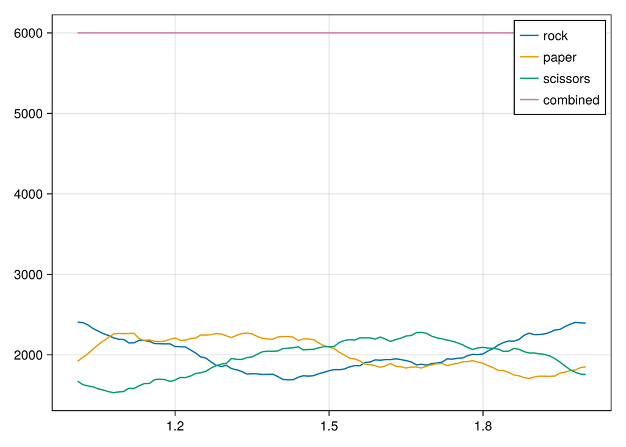

```julia
total_rocks = Int[]
total_papers = Int[]
total_scissors = Int[]
times = Float64[]
for group in snapshots
    # Julia dimensions are (z, y, x, species)
    totals = vec(sum(collect(group["chem/dc"]);dims=(1,2,3)))
    push!(times, attrs(group)["time (s)"])
    push!(total_rocks, totals[s.diffusing.R])
    push!(total_papers, totals[s.diffusing.P])
    push!(total_scissors, totals[s.diffusing.S])
end


figure, axis, lineplot = lines(times, total_rocks; label="rock")
lines!(times, total_papers; label="paper")
lines!(times, total_scissors; label="scissors")
lines!(
    times,
    total_scissors.+total_papers.+total_rocks;
    label="combined")
axislegend()
current_figure()
```

If you are using VSCode or Jupyter the figure will be displayed.

If you are using the REPL, save the figure as a PDF to view it.

```julia
save("tutorial2-plot.pdf", current_figure())
```